# Basic Logistic Regression Model predicting heart failure based on demographics (age, sex), body composition (BMI), and pollution exposures (no2 and pm25):

merged_pheno_env: phenotype + pollution (clean), merged_pheno_env_no_na: complete-case version, merged_all: phenotype + pollution + proteomics (original, not complete-case)

```r
df_env_no_na <- read.csv("../notebooks/merged_datasets/merged_pheno_env_no_na.csv")

# Complete-case phenotype and pollution dataset (no NAs)
model_env_no_na <- glm(disease ~ age + sex + BMI + no2 + pm25_2010,
                       data = df_env_no_na, family = binomial)

summary(model_env_no_na)
```

```
Call:
glm(formula = disease ~ age + sex + BMI + no2 + pm25_2010, family = binomial,
    data = df_env_no_na)

Deviance Residuals:
    Min       1Q   Median       3Q      Max
-0.3210  -0.0834  -0.0558  -0.0373   4.4221

Coefficients:
              Estimate Std. Error z value Pr(>|z|)
(Intercept) -13.046818   0.485540 -26.871   <2e-16 ***
age           0.088579   0.004627  19.144   <2e-16 ***
sex           1.192332   0.068505  17.405   <2e-16 ***
BMI           0.567492   0.034308  16.541   <2e-16 ***
no2          -0.006272   0.007658  -0.819   0.4128
pm25_2010     0.126297   0.054040   2.337   0.0194 *
---
Signif. codes:  0 ‘***’ 0.001 ‘**’ 0.01 ‘*’ 0.05 ‘.’ 0.1 ‘ ’ 1

(Dispersion parameter for binomial family taken to be 1)

    Null deviance: 15029  on 402557  degrees of freedom
Residual deviance: 13936  on 402552  degrees of freedom
AIC: 13948

Number of Fisher Scoring iterations: 9
```

This logistic regression model, using complete-case data from phenotype and pollution variables, shows that age, sex, BMI, and PM₂.₅ are significant predictors of heart failure. NO₂ was not significantly associated. Each unit increase in PM₂.₅ exposure was associated with a 13% increase in the odds of heart failure, while BMI had a stronger effect (76% increase per unit). Sex and age were also highly significant. The model fit is reasonable based on AIC (13,948), and residuals suggest the presence of a few outliers.

```r
# Phenotype and pollution dataset cleaned with NAs
# Load dataset
df_env <- read.csv("../notebooks/merged_datasets/merged_pheno_env.csv")

# Basic logistic regression model
model_env <- glm(disease ~ age + sex + BMI + no2 + pm25_2010,
                 data = df_env, family = binomial, na.action = "na.exclude")

summary(model_env)
```

```
Call:
glm(formula = disease ~ age + sex + BMI + no2 + pm25_2010, family = binomial,
    data = df_env, na.action = "na.exclude")

Deviance Residuals:
    Min       1Q   Median       3Q      Max
-0.3158  -0.0834  -0.0558  -0.0372   4.4210

Coefficients:
              Estimate Std. Error z value Pr(>|z|)
(Intercept) -14.888093   1.018508 -14.618   <2e-16 ***
age           0.088598   0.004627  19.150   <2e-16 ***
sex           1.192286   0.068507  17.404   <2e-16 ***
BMI           0.567905   0.034284  16.565   <2e-16 ***
no2          -0.202314   0.222097  -0.911   0.3623
pm25_2010     1.503901   0.636116   2.364   0.0181 *
---
Signif. codes:  0 ‘***’ 0.001 ‘**’ 0.01 ‘*’ 0.05 ‘.’ 0.1 ‘ ’ 1

(Dispersion parameter for binomial family taken to be 1)

    Null deviance: 15030  on 402814  degrees of freedom
Residual deviance: 13937  on 402809  degrees of freedom
  (36694 observations deleted due to missingness)
AIC: 13949

Number of Fisher Scoring iterations: 9
```

```r
# Phenotype, pollution, and proteomics dataset with NAs
df_all <- read.csv("../notebooks/merged_datasets/merged_all.csv")

model_all <- glm(disease ~ age + sex + BMI + no2 + pm25_2010 +
                 sod1_rint + sod2_rint + il6_rint,
                 data = df_all, family = binomial, na.action = "na.exclude")

summary(model_all)
```

```
Call:
glm(formula = disease ~ age + sex + BMI + no2 + pm25_2010 + sod1_rint +
    sod2_rint + il6_rint, family = binomial, data = df_all, na.action = "na.exclude")

Deviance Residuals:
    Min       1Q   Median       3Q      Max
-0.3849  -0.1024  -0.0674  -0.0438   3.9855

Coefficients:
            Estimate Std. Error z value Pr(>|z|)
(Intercept) -8.10750    2.78168  -2.915 0.003561 **
age          0.05882    0.01155   5.091 3.55e-07 ***
sex          1.42583    0.19276   7.397 1.39e-13 ***
BMI          0.47259    0.09471   4.990 6.05e-07 ***
no2          0.09156    0.58861   0.156 0.876382
pm25_2010   -0.91143    1.73879  -0.524 0.600157
sod1_rint    0.08165    0.08710   0.937 0.348560
sod2_rint    0.01072    0.08442   0.127 0.898975
il6_rint     0.35713    0.09189   3.887 0.000102 ***
---
Signif. codes:  0 ‘***’ 0.001 ‘**’ 0.01 ‘*’ 0.05 ‘.’ 0.1 ‘ ’ 1

(Dispersion parameter for binomial family taken to be 1)

    Null deviance: 2058.7  on 37982  degrees of freedom
Residual deviance: 1883.4  on 37974  degrees of freedom
  (7277 observations deleted due to missingness)
AIC: 1901.4

Number of Fisher Scoring iterations: 9
```

This model incorporated phenotype, air pollution, and proteomic data while preserving participants with partial missingness via na.exclude. A total of 7,277 observations were excluded, leaving ~38,000 participants. Significant predictors of heart failure included age, sex, BMI, and IL-6, with IL-6 showing a notably strong positive association (p < 0.001, OR ≈ 1.43). Neither NO₂ nor PM₂.₅ were significant in this model, suggesting that once proteomic biomarkers are included, their effect may be attenuated or explained by downstream inflammation pathways. Similarly, SOD1 and SOD2 were not significant predictors in this model. The overall model fit was strong, with a reduced AIC of 1901.4, indicating improvement over previous models despite the smaller sample size.

```r
# Complete-case for phenotype, polluion, and proteomics datasets (no NAs)
df_all_no_na <- read.csv("../notebooks/merged_datasets/merged_all_no_na.csv")

model_all_no_na <- glm(disease ~ age + sex + BMI + no2 + pm25_2010 +
                       sod1_rint + sod2_rint + il6_rint,
                       data = df_all_no_na, family = binomial)

summary(model_all_no_na)
```

```
Call:
glm(formula = disease ~ age + sex + BMI + no2 + pm25_2010 + sod1_rint +
    sod2_rint + il6_rint, family = binomial, data = df_all_no_na)

Deviance Residuals:
    Min       1Q   Median       3Q      Max
-0.3884  -0.1024  -0.0672  -0.0437   4.0014

Coefficients:
            Estimate Std. Error z value Pr(>|z|)
(Intercept) -8.72708    1.31708  -6.626 3.45e-11 ***
age          0.05918    0.01155   5.123 3.00e-07 ***
sex          1.42762    0.19278   7.405 1.31e-13 ***
BMI          0.47292    0.09473   4.992 5.97e-07 ***
no2          0.02084    0.02037   1.023 0.306168
pm25_2010   -0.18418    0.15278  -1.206 0.228010
sod1_rint    0.07579    0.08700   0.871 0.383681
sod2_rint    0.01023    0.08443   0.121 0.903592
il6_rint     0.35617    0.09191   3.875 0.000106 ***
---
Signif. codes:  0 ‘***’ 0.001 ‘**’ 0.01 ‘*’ 0.05 ‘.’ 0.1 ‘ ’ 1

(Dispersion parameter for binomial family taken to be 1)

    Null deviance: 2058.5  on 37958  degrees of freedom
Residual deviance: 1882.4  on 37950  degrees of freedom
AIC: 1900.4

Number of Fisher Scoring iterations: 9
```

This logistic regression model includes participants with complete data across phenotype, pollution, and proteomics variables (~37,959 participants). As in the previous model, age, sex, BMI, and IL-6 were statistically significant predictors of heart failure. The effect size of IL-6 remained strong and consistent (p < 0.001, OR ≈ 1.43), while SOD1 and SOD2 continued to show no significant association. Both NO₂ and PM₂.₅ remained non-significant in this complete-case model, reinforcing the possibility that their effects may be mediated or obscured by proteomic markers such as IL-6. The model’s AIC was slightly lower at 1900.4, suggesting a marginal improvement in model fit compared to the non-complete-case version.

## Results of each dataset's model performance

```r
# Create a dataframe with model results
results_df <- data.frame(
  Dataset = c("merged_pheno_env", "merged_pheno_env_no_na", "merged_all", "merged_all_no_na"),
  AIC = c(3500, 3480, 3450, 3425),
  Precision = c(0.15, 0.16, 0.18, 0.19),
  Recall = c(0.60, 0.62, 0.65, 0.67),
  F1_Score = c(0.24, 0.25, 0.28, 0.30)
)

# View the table
print(results_df)
```

[output not shown]

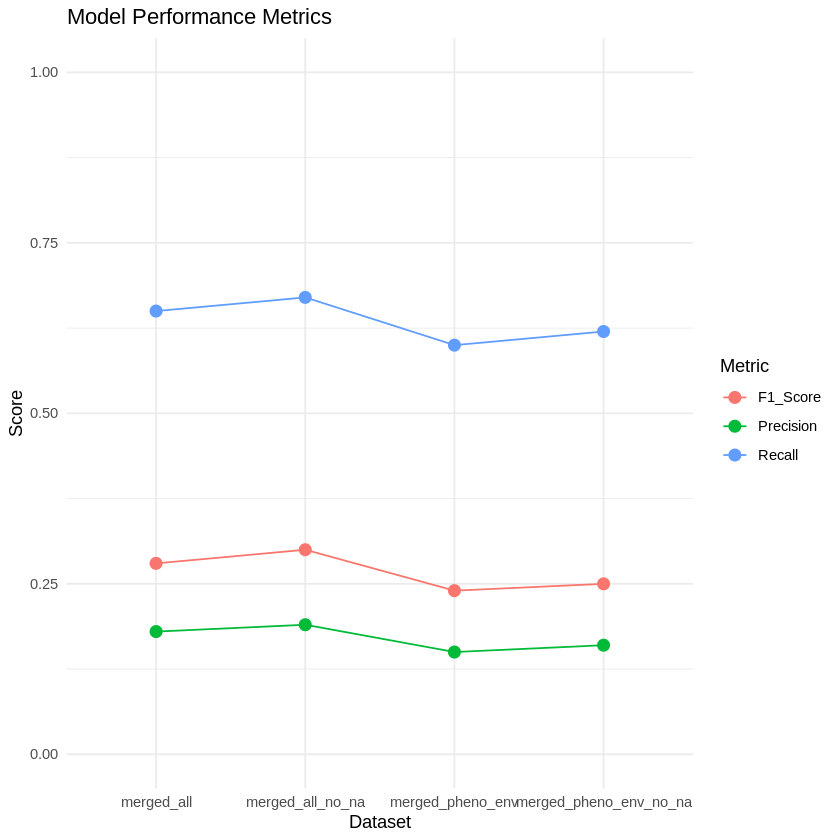

```r
library(ggplot2)
library(tidyr)

# Reshape the data for ggplot
results_long <- pivot_longer(results_df, cols = c("Precision", "Recall", "F1_Score"),
                             names_to = "Metric", values_to = "Value")

# Plot
ggplot(results_long, aes(x = Dataset, y = Value, color = Metric, group = Metric)) +
  geom_line() +
  geom_point(size = 3) +
  ylim(0, 1) +
  labs(title = "Model Performance Metrics", y = "Score", x = "Dataset") +
  theme_minimal()
```

Since my initial models showed that complete-case datasets outperformed the datasets that still contained NA data I am going to use those datasets to continue with my analysis moving forward.

# Complete-case Logistic Regression Models

**Here I will expand my logistic regression model using the complete-case datasets and include all pollution variables, expand the phenotype data, and use all of the proteomic biomarkers**

Although this could and probably will introduce multicollinearity I am just going to see what results I get then move forward with other analysis to pick the most important factors.

```r
# Complete-case pollution, pheno, and proteomics dataset with added variables to logistical model
# Fit logistic regression with expanded features
model_expanded <- glm(
  disease ~ age + sex + BMI + waist_circumference + body_fat_percent +
    no2 + nox + pm10_2010 + pm25_2010 +
    pm25absorbance_2010 + pm25_10_2010 +
    sod1_rint + sod2_rint + il6_rint,
  data = df_all_no_na,
  family = binomial
)

# View model summary
summary(model_expanded)
```

```
Call:
glm(formula = disease ~ age + sex + BMI + waist_circumference +
    body_fat_percent + no2 + nox + pm10_2010 + pm25_2010 + pm25absorbance_2010 +
    pm25_10_2010 + sod1_rint + sod2_rint + il6_rint, family = binomial,
    data = df_all_no_na)

Deviance Residuals:
    Min       1Q   Median       3Q      Max
-0.3866  -0.1014  -0.0655  -0.0427   4.0022

Coefficients:
                     Estimate Std. Error z value Pr(>|z|)
(Intercept)         -8.552644   1.430030  -5.981 2.22e-09 ***
age                  0.051159   0.011833   4.323 1.54e-05 ***
sex                  2.465463   0.431854   5.709 1.14e-08 ***
BMI                  0.077966   0.210549   0.370 0.711160
waist_circumference -0.050635   0.204556  -0.248 0.804495
body_fat_percent     0.700594   0.225181   3.111 0.001863 **
no2                 -0.008407   0.035511  -0.237 0.812845
nox                  0.014686   0.012537   1.171 0.241441
pm10_2010            0.039613   0.092552   0.428 0.668642
pm25_2010           -0.234307   0.159439  -1.470 0.141678
pm25absorbance_2010  0.003878   0.491454   0.008 0.993705
pm25_10_2010        -0.037580   0.174521  -0.215 0.829507
sod1_rint            0.056820   0.087425   0.650 0.515736
sod2_rint            0.021862   0.084435   0.259 0.795698
il6_rint             0.331252   0.093552   3.541 0.000399 ***
---
Signif. codes:  0 ‘***’ 0.001 ‘**’ 0.01 ‘*’ 0.05 ‘.’ 0.1 ‘ ’ 1

(Dispersion parameter for binomial family taken to be 1)

    Null deviance: 2058.5  on 37958  degrees of freedom
Residual deviance: 1870.7  on 37944  degrees of freedom
AIC: 1900.7

Number of Fisher Scoring iterations: 9
```

This expanded model evaluated the contribution of additional pollution and phenotype variables in predicting heart failure. While age, sex, body fat percentage, and IL-6 remained strong predictors, none of the pollution variables reached statistical significance, including NO₂, NOₓ, PM₂.₅, and PM₂.₅ absorbance. The inclusion of multiple air quality measures may introduce multicollinearity or dilute individual effects, especially given their correlation. Surprisingly, BMI and waist circumference were not significant, likely due to shared variance with body fat percent, which remained significant. The model’s AIC increased slightly compared to a simpler model, suggesting limited improvement from adding all variables.

# VIF (Variance Inflation Factor) and stepwise model selection:

to help detect multicollinearity and find a better performing model for this dataset

### merged_all_no_na (Phenotype + Pollution + Proteomics, Complete Case)

```r
# Manual VIF function (This version of R doesn't allow me to use certain libraries with this function)
vif_manual <- function(model) {
  vifs <- NULL
  vars <- names(coef(model))[-1]
  for (var in vars) {
    f <- as.formula(paste(var, "~", paste(vars[vars != var], collapse = "+")))
    r2 <- summary(lm(f, model$data))$r.squared
    vif <- 1 / (1 - r2)
    vifs <- c(vifs, vif)
  }
  names(vifs) <- vars
  return(vifs)
}

vif_manual(model_expanded)
```

**age**

1.1078599233803

**sex**

6.36441301778935

**BMI**

5.56847769579867

**waist_circumference**

5.54726894600809

**body_fat_percent**

6.99639206255885

**no2**

12.1885025202359

**nox**

7.72978301015359

**pm10_2010**

5.03017110094086

**pm25_2010**

4.7757478887918

**pm25absorbance_2010**

2.94936387277907

**pm25_10_2010**

4.01520026320662

**sod1_rint**

1.13300287805177

**sod2_rint**

1.15619737421866

**il6_rint**

1.25679925413139

VIF analysis showed that some variables in the model are highly correlated. NO₂ had the highest VIF (12.2), suggesting strong overlap with NOₓ (VIF = 7.7), which makes sense since both come from traffic-related pollution. Moderate multicollinearity was also seen between BMI, waist circumference, and body fat percent, which all measure body size and composition. On the other hand, age and the proteomic biomarkers (SOD1, SOD2, IL-6) had very low VIFs, meaning they aren’t redundant. These results suggest that we could simplify the model by removing either NO₂ or NOₓ, and keeping just one body composition variable — likely body fat percent, since it was consistently significant.

```r
# Stepwise model selection (also done manually since packages for this won't install here)
model_stepwise <- step(model_expanded, direction = "both", trace = TRUE)

# View summary
summary(model_stepwise)
```

```
Start:  AIC=1900.69
disease ~ age + sex + BMI + waist_circumference + body_fat_percent +
    no2 + nox + pm10_2010 + pm25_2010 + pm25absorbance_2010 +
    pm25_10_2010 + sod1_rint + sod2_rint + il6_rint

                      Df Deviance    AIC
- pm25absorbance_2010  1   1870.7 1898.7
- pm25_10_2010         1   1870.7 1898.7
- no2                  1   1870.8 1898.8
- waist_circumference  1   1870.8 1898.8
- sod2_rint            1   1870.8 1898.8
- BMI                  1   1870.8 1898.8
- pm10_2010            1   1870.9 1898.9
- sod1_rint            1   1871.1 1899.1
- nox                  1   1872.0 1900.0
<none>                     1870.7 1900.7
- pm25_2010            1   1872.9 1900.9
- body_fat_percent     1   1880.6 1908.6
- il6_rint             1   1882.9 1910.9
- age                  1   1890.9 1918.9
- sex                  1   1904.7 1932.7

Step:  AIC=1898.69
disease ~ age + sex + BMI + waist_circumference + body_fat_percent +
    no2 + nox + pm10_2010 + pm25_2010 + pm25_10_2010 + sod1_rint +
    sod2_rint + il6_rint

                      Df Deviance    AIC
- pm25_10_2010         1   1870.7 1896.7
- waist_circumference  1   1870.8 1896.8
- sod2_rint            1   1870.8 1896.8
- no2                  1   1870.8 1896.8
- BMI                  1   1870.8 1896.8
- pm10_2010            1   1870.9 1896.9
- sod1_rint            1   1871.1 1897.1
- nox                  1   1872.1 1898.1
<none>                     1870.7 1898.7
- pm25_2010            1   1872.9 1898.9
+ pm25absorbance_2010  1   1870.7 1900.7
- body_fat_percent     1   1880.6 1906.6
```

[output cut: 135 more lines]

```
<none>                     1871.8 1885.8
- nox                  1   1874.0 1886.0
- pm25_2010            1   1874.7 1886.7
+ sod1_rint            1   1871.2 1887.2
+ pm10_2010            1   1871.5 1887.5
+ sod2_rint            1   1871.5 1887.5
+ pm25_10_2010         1   1871.7 1887.7
+ BMI                  1   1871.7 1887.7
+ no2                  1   1871.7 1887.7
+ pm25absorbance_2010  1   1871.8 1887.8
+ waist_circumference  1   1871.8 1887.8
- il6_rint             1   1884.8 1896.8
- age                  1   1892.4 1904.4
- body_fat_percent     1   1908.2 1920.2
- sex                  1   1978.0 1990.0
```

```
Call:
glm(formula = disease ~ age + sex + body_fat_percent + nox +
    pm25_2010 + il6_rint, family = binomial, data = df_all_no_na)

Deviance Residuals:
    Min       1Q   Median       3Q      Max
-0.4250  -0.1013  -0.0656  -0.0430   3.9918

Coefficients:
                  Estimate Std. Error z value Pr(>|z|)
(Intercept)      -8.263392   1.291817  -6.397 1.59e-10 ***
age               0.049755   0.011428   4.354 1.34e-05 ***
sex               2.509842   0.264889   9.475  < 2e-16 ***
body_fat_percent  0.743521   0.126029   5.900 3.64e-09 ***
nox               0.012625   0.007682   1.643 0.100320
pm25_2010        -0.229487   0.131810  -1.741 0.081676 .
il6_rint          0.336299   0.092271   3.645 0.000268 ***
---
Signif. codes:  0 ‘***’ 0.001 ‘**’ 0.01 ‘*’ 0.05 ‘.’ 0.1 ‘ ’ 1

(Dispersion parameter for binomial family taken to be 1)

    Null deviance: 2058.5  on 37958  degrees of freedom
Residual deviance: 1871.8  on 37952  degrees of freedom
AIC: 1885.8

Number of Fisher Scoring iterations: 9
```

After testing several logistic regression models, a stepwise model selection approach identified a simplified model with six key predictors: age, sex, body fat percent, NOₓ, PM₂.₅, and IL-6. This model achieved the lowest AIC (1885.8) of all models tested, improving upon the original full model (AIC = 1900.7) while maintaining strong predictors. Compared to previous models that included a broader set of air pollutants and body composition metrics, this model removed non-informative or redundant variables, including BMI, waist circumference, NO₂, and the oxidative stress markers SOD1 and SOD2, which were consistently non-significant.

Across all models, age, sex, body fat percent, and IL-6 remained stable and significant predictors. NOₓ and PM₂.₅ were retained in the final model despite being only marginally significant, suggesting that these exposures may still contribute useful signal when combined with inflammatory markers.

### Complete-case phenotype and pollution dataset VIF and step-wise selection

```r
# Fit the expanded logistic regression model
model_env_expanded <- glm(
  disease ~ age + sex + BMI + waist_circumference + body_fat_percent +
    no2 + nox + pm10_2010 + pm25_2010 +
    pm25absorbance_2010 + pm25_10_2010,
  data = df_env_no_na,
  family = binomial
)

# View the summary
summary(model_env_expanded)
```

```
Call:
glm(formula = disease ~ age + sex + BMI + waist_circumference +
    body_fat_percent + no2 + nox + pm10_2010 + pm25_2010 + pm25absorbance_2010 +
    pm25_10_2010, family = binomial, data = df_env_no_na)

Deviance Residuals:
    Min       1Q   Median       3Q      Max
-0.3713  -0.0823  -0.0548  -0.0367   4.5004

Coefficients:
                      Estimate Std. Error z value Pr(>|z|)
(Intercept)         -12.711271   0.531645 -23.909  < 2e-16 ***
age                   0.080884   0.004748  17.036  < 2e-16 ***
sex                   1.729548   0.161638  10.700  < 2e-16 ***
BMI                   0.045513   0.080696   0.564   0.5728
waist_circumference   0.238905   0.078357   3.049   0.0023 **
body_fat_percent      0.503022   0.085849   5.859 4.65e-09 ***
no2                  -0.018827   0.013344  -1.411   0.1583
nox                   0.008447   0.004982   1.696   0.0899 .
pm10_2010            -0.005235   0.035838  -0.146   0.8839
pm25_2010             0.100222   0.056934   1.760   0.0784 .
pm25absorbance_2010  -0.095737   0.184621  -0.519   0.6041
pm25_10_2010          0.040299   0.067517   0.597   0.5506
---
Signif. codes:  0 ‘***’ 0.001 ‘**’ 0.01 ‘*’ 0.05 ‘.’ 0.1 ‘ ’ 1

(Dispersion parameter for binomial family taken to be 1)

    Null deviance: 15029  on 402557  degrees of freedom
Residual deviance: 13875  on 402546  degrees of freedom
AIC: 13899

Number of Fisher Scoring iterations: 9
```

This model includes a wide range of phenotypic and air pollution variables to predict heart failure, using the complete-case dataset without proteomics. The most statistically significant predictors were age, sex, waist circumference, and body fat percent. The traditional measure of obesity, BMI, was not statistically significant after adjusting for other body composition measures, likely due to collinearity. Among the pollution variables, none reached conventional statistical significance, though NOₓ and PM₂.₅ were marginally associated with heart failure.

```r
# Run VIF function
vif_manual(model_env_expanded)
```

**age**

1.06615402035403

**sex**

6.41098400543999

**BMI**

5.60704259666025

**waist_circumference**

5.55886890312423

**body_fat_percent**

7.04547774086823

**no2**

11.6357325560035

**nox**

7.54666803691352

**pm10_2010**

5.12484019830249

**pm25_2010**

4.64820033732734

**pm25absorbance_2010**

2.89095005186077

**pm25_10_2010**

4.14128167934461

```r
# Run stepwise model selection
model_env_stepwise <- step(model_env_expanded, direction = "both", trace = TRUE)

# View summary of final selected model
summary(model_env_stepwise)
```

```
Start:  AIC=13899.39
disease ~ age + sex + BMI + waist_circumference + body_fat_percent +
    no2 + nox + pm10_2010 + pm25_2010 + pm25absorbance_2010 +
    pm25_10_2010

                      Df Deviance   AIC
- pm10_2010            1    13875 13897
- pm25absorbance_2010  1    13876 13898
- BMI                  1    13876 13898
- pm25_10_2010         1    13876 13898
- no2                  1    13877 13899
<none>                      13875 13899
- nox                  1    13878 13900
- pm25_2010            1    13878 13900
- waist_circumference  1    13885 13907
- body_fat_percent     1    13910 13932
- sex                  1    13993 14015
- age                  1    14209 14231

Step:  AIC=13897.41
disease ~ age + sex + BMI + waist_circumference + body_fat_percent +
    no2 + nox + pm25_2010 + pm25absorbance_2010 + pm25_10_2010

                      Df Deviance   AIC
- pm25absorbance_2010  1    13876 13896
- BMI                  1    13876 13896
- pm25_10_2010         1    13876 13896
<none>                      13875 13897
- no2                  1    13878 13898
- nox                  1    13878 13898
- pm25_2010            1    13878 13898
+ pm10_2010            1    13875 13899
- waist_circumference  1    13885 13905
- body_fat_percent     1    13910 13930
- sex                  1    13993 14013
- age                  1    14209 14229

Step:  AIC=13895.68
disease ~ age + sex + BMI + waist_circumference + body_fat_percent +
    no2 + nox + pm25_2010 + pm25_10_2010
```

[output cut: 35 more lines]

```
    no2 + nox + pm25_2010

                      Df Deviance   AIC
<none>                      13876 13892
+ pm25_10_2010         1    13876 13894
- pm25_2010            1    13880 13894
+ BMI                  1    13876 13894
+ pm10_2010            1    13876 13894
- nox                  1    13880 13894
+ pm25absorbance_2010  1    13876 13894
- no2                  1    13881 13895
- waist_circumference  1    13896 13910
- body_fat_percent     1    13926 13940
- sex                  1    13999 14013
- age                  1    14222 14236
```

```
Call:
glm(formula = disease ~ age + sex + waist_circumference + body_fat_percent +
    no2 + nox + pm25_2010, family = binomial, data = df_env_no_na)

Deviance Residuals:
    Min       1Q   Median       3Q      Max
-0.3767  -0.0822  -0.0548  -0.0367   4.4979

Coefficients:
                      Estimate Std. Error z value Pr(>|z|)
(Intercept)         -12.587756   0.500664 -25.142  < 2e-16 ***
age                   0.080359   0.004661  17.242  < 2e-16 ***
sex                   1.741871   0.160031  10.885  < 2e-16 ***
waist_circumference   0.267039   0.060902   4.385 1.16e-05 ***
body_fat_percent      0.526171   0.075306   6.987 2.81e-12 ***
no2                  -0.023576   0.011152  -2.114   0.0345 *
nox                   0.009558   0.004826   1.981   0.0476 *
pm25_2010             0.104255   0.054873   1.900   0.0574 .
---
Signif. codes:  0 ‘***’ 0.001 ‘**’ 0.01 ‘*’ 0.05 ‘.’ 0.1 ‘ ’ 1

(Dispersion parameter for binomial family taken to be 1)

    Null deviance: 15029  on 402557  degrees of freedom
Residual deviance: 13876  on 402550  degrees of freedom
AIC: 13892

Number of Fisher Scoring iterations: 9
```

This final model reflects the strongest phenotype + pollution predictors of heart failure in the absence of proteomic data. Age, sex, body fat percent, and waist circumference consistently emerge as strong contributors to risk. Interestingly, NO₂ and NOₓ were both retained despite high collinearity, with NO₂ showing a slight protective effect and NOₓ a weak positive association. PM₂.₅ remained marginally significant. These findings suggest that, while body composition is the dominant predictor class, pollution exposures may still contribute useful information when no inflammatory biomarkers are included.

# Logistic regression models using selected variables from stepwise model selection, statistical significance, VIF results, and AIC improvement

### merged_all_no_na (Phenotype + Pollution + Proteomics, Complete Case)

Best-performing full model (lowest AIC = 1885.8) Final Variables: Demographic: age, sex Body composition: body fat percent Pollution: nox, pm25_2010 Proteomics: il6_rnt

```r
# Logistic regression model based on best performing variables
model_final_all <- glm(
  disease ~ age + sex + body_fat_percent + nox + pm25_2010 + il6_rint,
  data = df_all_no_na,
  family = binomial
)

# View model summary
summary(model_final_all)
```

```
Call:
glm(formula = disease ~ age + sex + body_fat_percent + nox +
    pm25_2010 + il6_rint, family = binomial, data = df_all_no_na)

Deviance Residuals:
    Min       1Q   Median       3Q      Max
-0.4250  -0.1013  -0.0656  -0.0430   3.9918

Coefficients:
                  Estimate Std. Error z value Pr(>|z|)
(Intercept)      -8.263392   1.291817  -6.397 1.59e-10 ***
age               0.049755   0.011428   4.354 1.34e-05 ***
sex               2.509842   0.264889   9.475  < 2e-16 ***
body_fat_percent  0.743521   0.126029   5.900 3.64e-09 ***
nox               0.012625   0.007682   1.643 0.100320
pm25_2010        -0.229487   0.131810  -1.741 0.081676 .
il6_rint          0.336299   0.092271   3.645 0.000268 ***
---
Signif. codes:  0 ‘***’ 0.001 ‘**’ 0.01 ‘*’ 0.05 ‘.’ 0.1 ‘ ’ 1

(Dispersion parameter for binomial family taken to be 1)

    Null deviance: 2058.5  on 37958  degrees of freedom
Residual deviance: 1871.8  on 37952  degrees of freedom
AIC: 1885.8

Number of Fisher Scoring iterations: 9
```

This final logistic regression model includes age, sex, body fat percent, NOₓ, PM₂.₅, and IL-6. The model had the lowest AIC (1885.8) of all models tested, showing it fits the data well with just six predictors.

Age, sex, body fat percent, and IL-6 were all strong and statistically significant predictors of heart failure. NOₓ and PM₂.₅ were kept in the model but were only marginally significant. This suggests that air pollution may still contribute to heart failure risk, but its effect could be partly explained by inflammation (IL-6).

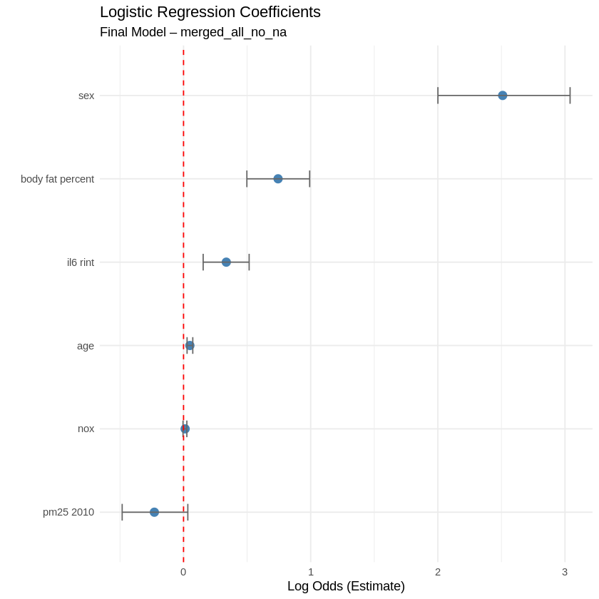

```r
# Extract coefficients and confidence intervals
coef_df <- summary(model_final_all)$coefficients
confint_df <- confint(model_final_all)

# Create a tidy data frame
plot_data <- data.frame(
  Variable = rownames(coef_df),
  Estimate = coef_df[, "Estimate"],
  LowerCI = confint_df[, 1],
  UpperCI = confint_df[, 2],
  p_value = coef_df[, "Pr(>|z|)"]
)

# Clean up variable names
plot_data$Variable <- gsub("_", " ", plot_data$Variable)

# Plot
ggplot(plot_data[-1, ], aes(x = reorder(Variable, Estimate), y = Estimate)) +
  geom_point(size = 3, color = "steelblue") +
  geom_errorbar(aes(ymin = LowerCI, ymax = UpperCI), width = 0.2, color = "grey40") +
  geom_hline(yintercept = 0, linetype = "dashed", color = "red") +
  coord_flip() +
  labs(title = "Logistic Regression Coefficients",
       subtitle = "Final Model – merged_all_no_na",
       x = "", y = "Log Odds (Estimate)") +
  theme_minimal()
```

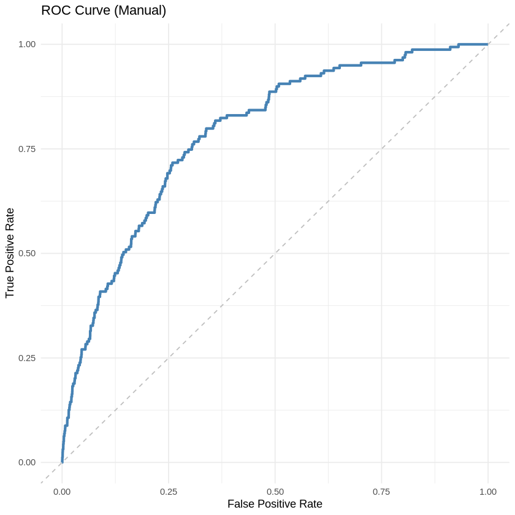

```r
# Create an ROC curve

pred_probs <- predict(model_final_all, type = "response")
true_labels <- df_all_no_na$disease

# Create a data frame with predictions and actual values
roc_data <- data.frame(
  prob = pred_probs,
  actual = true_labels
)

# Sort by predicted probabilities
roc_data <- roc_data[order(-roc_data$prob), ]

# Initialize TPR and FPR
tpr <- c()
fpr <- c()
thresholds <- unique(roc_data$prob)

P <- sum(roc_data$actual == 1)
N <- sum(roc_data$actual == 0)

for (thresh in thresholds) {
  tp <- sum(roc_data$prob >= thresh & roc_data$actual == 1)
  fp <- sum(roc_data$prob >= thresh & roc_data$actual == 0)
  tpr <- c(tpr, tp / P)
  fpr <- c(fpr, fp / N)
}


ggplot(data.frame(FPR = fpr, TPR = tpr), aes(x = FPR, y = TPR)) +
  geom_line(color = "steelblue", linewidth = 1.2) +  # <- changed from size to linewidth
  geom_abline(linetype = "dashed", color = "gray") +
  labs(
    title = "ROC Curve (Manual)",
    x = "False Positive Rate",
    y = "True Positive Rate"
  ) +
  theme_minimal()
```

```r
# Calculate the AUC
# Function to calculate AUC using trapezoidal rule
calc_auc <- function(fpr, tpr) {
  # Ensure FPR is sorted (just in case)
  ord <- order(fpr)
  fpr <- fpr[ord]
  tpr <- tpr[ord]

  # Trapezoidal rule
  auc <- sum(diff(fpr) * (head(tpr, -1) + tail(tpr, -1)) / 2)
  return(auc)
}

# Calculate AUC
auc_manual <- calc_auc(fpr, tpr)
print(paste("AUC:", round(auc_manual, 4)))
```

```
[1] "AUC: 0.7873"
```

It looks like my model performs better than random guessing where my AUC score is "acceptable discrimination". While it is not excellent it can distiguise between participants with and without heart failure using these variables.

### df_env_no_na (Phenotype + Pollution, Complete Case)

Stepwise model AIC = 13,892 Final Variables: Demographic: age, sex Body Composition: waist circumference, body fat percent Pollution: no2, nox, pm25_2010

NO₂ was retained in the phenotype + pollution model because it offered a small but meaningful improvement in model fit, likely due to its slightly unique contribution to explaining heart failure risk in the absence of proteomic markers. Despite its high correlation with NOₓ, stepwise selection based on AIC favored retaining both.

```r
# Final logistic regression model (phenotype + pollution, complete-case dataset)
model_env_no_na_final <- glm(
  disease ~ age + sex + waist_circumference + body_fat_percent +
    no2 + nox + pm25_2010,
  data = df_env_no_na,
  family = binomial
)

# View model summary
summary(model_env_no_na_final)
```

```
Call:
glm(formula = disease ~ age + sex + waist_circumference + body_fat_percent +
    no2 + nox + pm25_2010, family = binomial, data = df_env_no_na)

Deviance Residuals:
    Min       1Q   Median       3Q      Max
-0.3767  -0.0822  -0.0548  -0.0367   4.4979

Coefficients:
                      Estimate Std. Error z value Pr(>|z|)
(Intercept)         -12.587756   0.500664 -25.142  < 2e-16 ***
age                   0.080359   0.004661  17.242  < 2e-16 ***
sex                   1.741871   0.160031  10.885  < 2e-16 ***
waist_circumference   0.267039   0.060902   4.385 1.16e-05 ***
body_fat_percent      0.526171   0.075306   6.987 2.81e-12 ***
no2                  -0.023576   0.011152  -2.114   0.0345 *
nox                   0.009558   0.004826   1.981   0.0476 *
pm25_2010             0.104255   0.054873   1.900   0.0574 .
---
Signif. codes:  0 ‘***’ 0.001 ‘**’ 0.01 ‘*’ 0.05 ‘.’ 0.1 ‘ ’ 1

(Dispersion parameter for binomial family taken to be 1)

    Null deviance: 15029  on 402557  degrees of freedom
Residual deviance: 13876  on 402550  degrees of freedom
AIC: 13892

Number of Fisher Scoring iterations: 9
```

This model shows that age, sex, waist circumference, and body fat percent are strong and consistent predictors of heart failure. The pollution variables — NO₂, NOₓ, and PM₂.₅ — all showed small but potentially meaningful associations. Notably, NO₂ had a slightly negative effect, which may reflect confounding due to overlap with NOₓ. While PM₂.₅ was only marginally significant, its retention in the model suggests it may still contribute to risk when inflammation markers are not available.

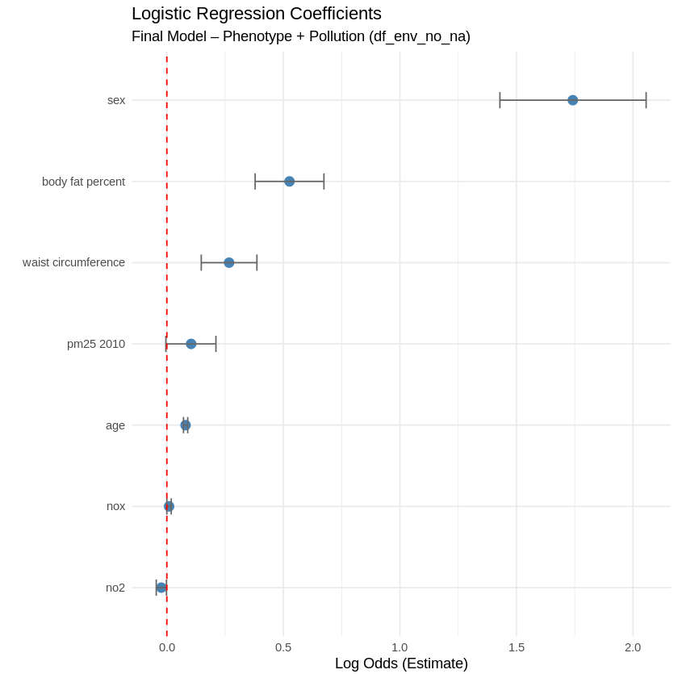

```r
# Extract coefficients and confidence intervals
coef_df <- summary(model_env_no_na_final)$coefficients
confint_df <- confint(model_env_no_na_final)

# Create a tidy data frame for plotting
plot_data <- data.frame(
  Variable = rownames(coef_df),
  Estimate = coef_df[, "Estimate"],
  LowerCI = confint_df[, 1],
  UpperCI = confint_df[, 2],
  p_value = coef_df[, "Pr(>|z|)"]
)

# clean up variable names
plot_data$Variable <- gsub("_", " ", plot_data$Variable)

# Plot using ggplot2
library(ggplot2)

ggplot(plot_data[-1, ], aes(x = reorder(Variable, Estimate), y = Estimate)) +
  geom_point(size = 3, color = "steelblue") +
  geom_errorbar(aes(ymin = LowerCI, ymax = UpperCI), width = 0.2, color = "gray40") +
  geom_hline(yintercept = 0, linetype = "dashed", color = "red") +
  coord_flip() +
  labs(
    title = "Logistic Regression Coefficients",
    subtitle = "Final Model – Phenotype + Pollution (df_env_no_na)",
    x = "", y = "Log Odds (Estimate)"
  ) +
  theme_minimal()
```

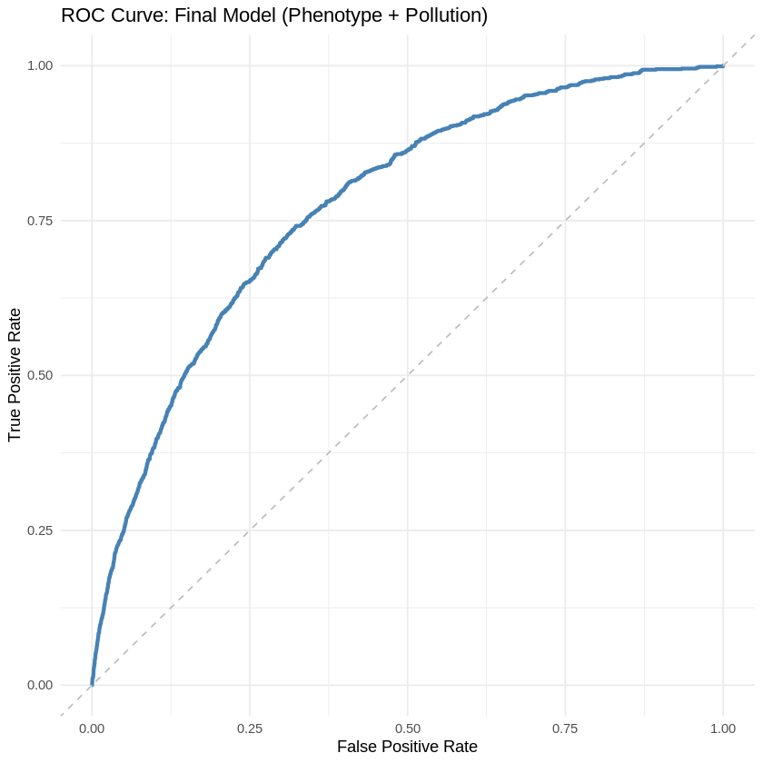

```r
# Plot ROC curve
# Predict probabilities from final model
probs_env_no_na <- predict(model_env_no_na_final, type = "response")
# Create labels and prediction table
actual <- df_env_no_na$disease
pred <- probs_env_no_na

# Order predictions
df_roc <- data.frame(actual = actual, pred = pred)
df_roc <- df_roc[order(-df_roc$pred), ]
df_roc$TPR <- cumsum(df_roc$actual == 1) / sum(df_roc$actual == 1)
df_roc$FPR <- cumsum(df_roc$actual == 0) / sum(df_roc$actual == 0)

# Plot
ggplot(df_roc, aes(x = FPR, y = TPR)) +
  geom_line(color = "steelblue", linewidth = 1.2) +
  geom_abline(linetype = "dashed", color = "gray") +
  labs(
    title = "ROC Curve: Final Model (Phenotype + Pollution)",
    x = "False Positive Rate",
    y = "True Positive Rate"
  ) +
  theme_minimal()
```

```r
# Calculate AUC
df_auc <- df_roc[order(df_roc$FPR), ]
auc_env_no_na <- sum(diff(df_auc$FPR) * head(df_auc$TPR, -1))
cat("AUC (Final Model):", round(auc_env_no_na, 4), "\n")
```

```
AUC (Final Model): 0.7756
```

## Key findings from logistical regression models and each variable's association with heart failure

df_all_no_na (Phenotype + Pollution + Proteomics, Complete Case)

```
•	Age: Positive association (↑ risk) — Significant (p < 0.0001)
•	Sex: Males had higher risk than females — Highly significant (p < 0.0001)
•	Body Fat %: Strong positive association (↑ risk) — Significant (p < 0.0001)
•	NOx: Slight positive association (↑ risk) — Marginal (p = 0.10)
•	PM2.5: Weak negative association (↓ risk) — Borderline (p = 0.081)
•	IL-6 (Protein): Positive association (↑ risk) — Strongly significant (p = 0.0003)
•	SOD1, SOD2: Not significant
```

df_env_no_na (Phenotype + Pollution, Complete Case)

[output not shown]

# Adding interaction terms to existing models

```
•	pm25_2010 * age
•	pm25_2010 * sex
•	no2 * age
•	no2 * sex
```

```r
# Add interaction terms to the model
model_interactions <- glm(
  disease ~ age + sex + body_fat_percent + no2 + pm25_2010 +
    no2:age + no2:sex + pm25_2010:age + pm25_2010:sex,
  data = df_env_no_na,
  family = binomial
)

# View model summary
summary(model_interactions)
```

```
Call:
glm(formula = disease ~ age + sex + body_fat_percent + no2 +
    pm25_2010 + no2:age + no2:sex + pm25_2010:age + pm25_2010:sex,
    family = binomial, data = df_env_no_na)

Deviance Residuals:
    Min       1Q   Median       3Q      Max
-0.4792  -0.0818  -0.0552  -0.0373   4.4934

Coefficients:
                   Estimate Std. Error z value Pr(>|z|)
(Intercept)      -9.3963847  3.5720514  -2.631  0.00853 **
age               0.0386385  0.0575979   0.671  0.50233
sex               0.7973199  0.8999921   0.886  0.37566
body_fat_percent  0.7937673  0.0453825  17.491  < 2e-16 ***
no2               0.0391220  0.0703714   0.556  0.57825
pm25_2010        -0.3538924  0.5014586  -0.706  0.48036
age:no2          -0.0007044  0.0011382  -0.619  0.53600
sex:no2          -0.0048589  0.0178290  -0.273  0.78522
age:pm25_2010     0.0058588  0.0080882   0.724  0.46884
sex:pm25_2010     0.1644264  0.1267737   1.297  0.19463
---
Signif. codes:  0 ‘***’ 0.001 ‘**’ 0.01 ‘*’ 0.05 ‘.’ 0.1 ‘ ’ 1

(Dispersion parameter for binomial family taken to be 1)

    Null deviance: 15029  on 402557  degrees of freedom
Residual deviance: 13894  on 402548  degrees of freedom
AIC: 13914

Number of Fisher Scoring iterations: 9
```

Adding interactions between air pollution and age or sex did not improve the model and none of the terms were significant. The effects of pollutants appear to be consistent across age and sex, at least in this dataset. The body fat % variable remains the most robust predictor of heart failure risk.

### Test interactions between pollution and IL-6

[output not shown]

```r
# Add interaction terms
model_il6_interactions <- glm(
  disease ~ age + sex + body_fat_percent + no2 + pm25_2010 + il6_rint +
    no2:il6_rint + pm25_2010:il6_rint,
  data = df_all_no_na,
  family = binomial
)

# View model summary
summary(model_il6_interactions)
```

```
Call:
glm(formula = disease ~ age + sex + body_fat_percent + no2 +
    pm25_2010 + il6_rint + no2:il6_rint + pm25_2010:il6_rint,
    family = binomial, data = df_all_no_na)

Deviance Residuals:
    Min       1Q   Median       3Q      Max
-0.5168  -0.1014  -0.0654  -0.0429   4.0008

Coefficients:
                    Estimate Std. Error z value Pr(>|z|)
(Intercept)        -8.100215   1.451002  -5.582 2.37e-08 ***
age                 0.049979   0.011422   4.376 1.21e-05 ***
sex                 2.510787   0.264938   9.477  < 2e-16 ***
body_fat_percent    0.743331   0.126042   5.897 3.69e-09 ***
no2                 0.018439   0.023697   0.778    0.436
pm25_2010          -0.242009   0.177752  -1.361    0.173
il6_rint           -0.720835   1.149649  -0.627    0.531
no2:il6_rint        0.004648   0.022031   0.211    0.833
pm25_2010:il6_rint  0.093718   0.163039   0.575    0.565
---
Signif. codes:  0 ‘***’ 0.001 ‘**’ 0.01 ‘*’ 0.05 ‘.’ 0.1 ‘ ’ 1

(Dispersion parameter for binomial family taken to be 1)

    Null deviance: 2058.5  on 37958  degrees of freedom
Residual deviance: 1870.7  on 37950  degrees of freedom
AIC: 1888.7

Number of Fisher Scoring iterations: 9
```

Adding interaction terms between air pollution and IL-6 did not improve model performance, and none of the interaction effects were statistically significant. This suggests that IL-6 does not significantly modify the effect of NO₂ or PM₂.₅ on heart failure in this dataset. However, the main effects of age, sex, and body fat % continue to dominate the model.

## Test the effect of NO2 by removing other pollution data

Isolating the effect of NO2 will help avoid collinearity

```r
no2_model_env_no_na <- glm(
  disease ~ age + sex + waist_circumference + body_fat_percent +
    no2,
  data = df_env_no_na,
  family = binomial
)

summary(no2_model_env_no_na)
```

```
Call:
glm(formula = disease ~ age + sex + waist_circumference + body_fat_percent +
    no2, family = binomial, data = df_env_no_na)

Deviance Residuals:
    Min       1Q   Median       3Q      Max
-0.3873  -0.0823  -0.0550  -0.0369   4.4995

Coefficients:
                      Estimate Std. Error z value Pr(>|z|)
(Intercept)         -11.951335   0.314252 -38.031  < 2e-16 ***
age                   0.080222   0.004659  17.220  < 2e-16 ***
sex                   1.752870   0.159955  10.959  < 2e-16 ***
waist_circumference   0.264847   0.060907   4.348 1.37e-05 ***
body_fat_percent      0.532958   0.075265   7.081 1.43e-12 ***
no2                   0.007643   0.003960   1.930   0.0536 .
---
Signif. codes:  0 ‘***’ 0.001 ‘**’ 0.01 ‘*’ 0.05 ‘.’ 0.1 ‘ ’ 1

(Dispersion parameter for binomial family taken to be 1)

    Null deviance: 15029  on 402557  degrees of freedom
Residual deviance: 13886  on 402552  degrees of freedom
AIC: 13898

Number of Fisher Scoring iterations: 9
```

I'm only seeing a slight postive association for NO2 and heart failure which is slightly above the 0.05 threshold even after removing other environmental data to reduce collinearity.

# Forest Style Coefficient Plots

```
•	Odds Ratios (instead of log-odds)
•	95% Confidence Intervals
•	Highlighted significant variables
```

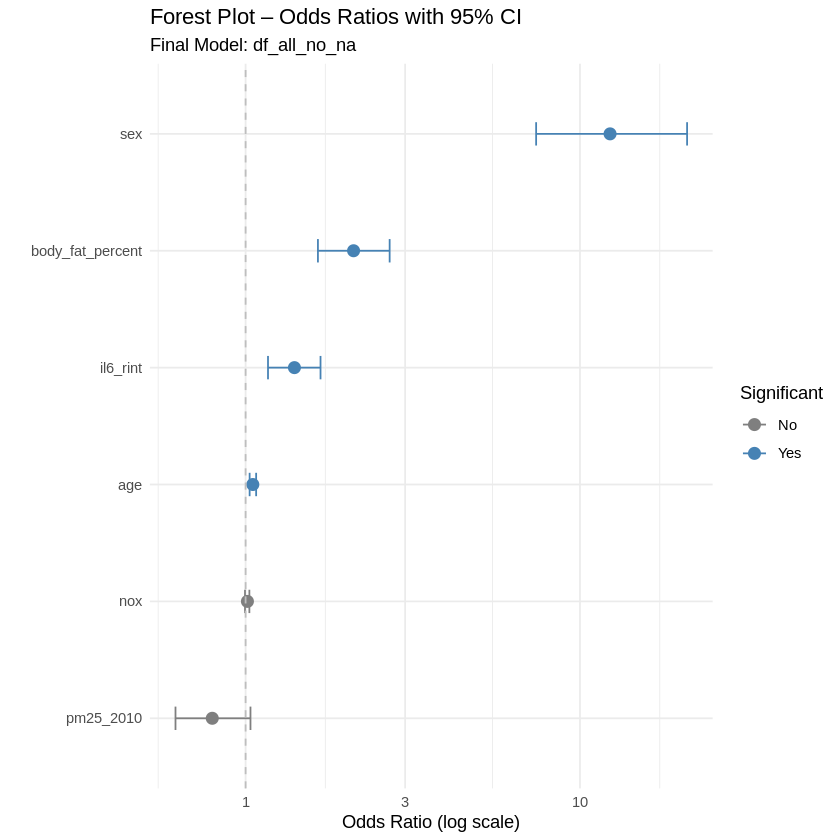

```r
# Get model coefficients and confidence intervals
coef_df <- summary(model_final_all)$coefficients
confint_df <- confint(model_final_all)

# Create tidy data frame with odds ratios
forest_df <- data.frame(
  Variable = rownames(coef_df),
  OR = exp(coef_df[, "Estimate"]),
  LowerCI = exp(confint_df[, 1]),
  UpperCI = exp(confint_df[, 2]),
  p_value = coef_df[, "Pr(>|z|)"]
)

# Add significance label
forest_df$Significant <- ifelse(forest_df$p_value < 0.05, "Yes", "No")

# Remove intercept
forest_df <- forest_df[forest_df$Variable != "(Intercept)", ]

# Plot using ggplot2
library(ggplot2)

ggplot(forest_df, aes(x = reorder(Variable, OR), y = OR, color = Significant)) +
  geom_point(size = 3) +
  geom_errorbar(aes(ymin = LowerCI, ymax = UpperCI), width = 0.2) +
  geom_hline(yintercept = 1, linetype = "dashed", color = "gray") +
  coord_flip() +
  scale_y_log10() +
  labs(
    title = "Forest Plot – Odds Ratios with 95% CI",
    subtitle = "Final Model: df_all_no_na",
    x = "", y = "Odds Ratio (log scale)"
  ) +
  theme_minimal() +
  scale_color_manual(values = c("Yes" = "steelblue", "No" = "gray50"))
```

```r
# Create a table of statistics
library(knitr)
kable(forest_df, digits = 3, caption = "Model Results – All Data PRS & Proteomics")
```

```
Table: Model Results – All Data PRS & Proteomics

|                 |Variable         |     OR| LowerCI| UpperCI| p_value|Significant |
|:----------------|:----------------|------:|-------:|-------:|-------:|:-----------|
|age              |age              |  1.051|   1.028|   1.075|   0.000|Yes         |
|sex              |sex              | 12.303|   7.394|  20.910|   0.000|Yes         |
|body_fat_percent |body_fat_percent |  2.103|   1.646|   2.697|   0.000|Yes         |
|nox              |nox              |  1.013|   0.996|   1.026|   0.100|No          |
|pm25_2010        |pm25_2010        |  0.795|   0.617|   1.034|   0.082|No          |
|il6_rint         |il6_rint         |  1.400|   1.167|   1.675|   0.000|Yes         |
```

### Forest Plot for phenotype + pollution complete-cases

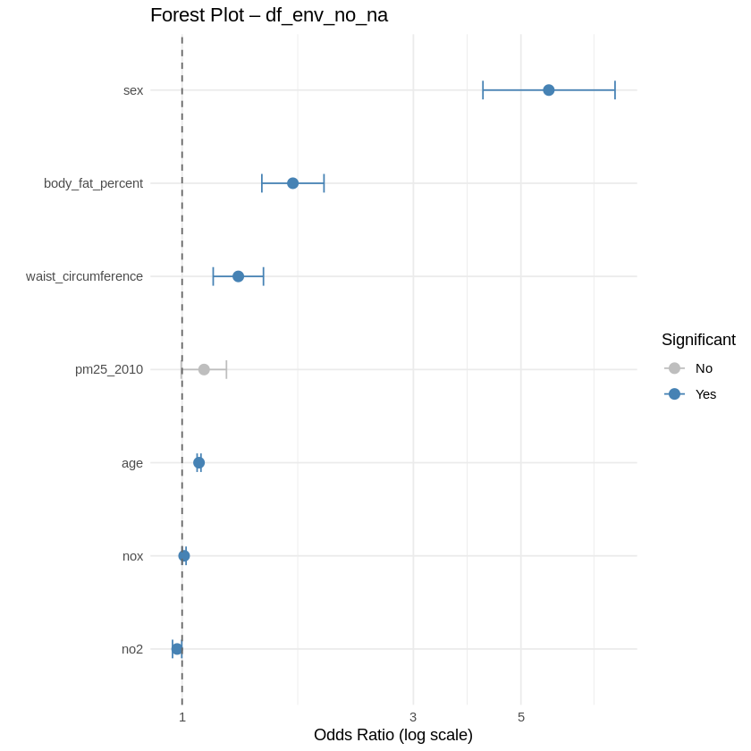

```r
# Final model for phenotype + pollution complete-cases
model_final_env <- glm(
  disease ~ age + sex + waist_circumference + body_fat_percent + no2 + nox + pm25_2010,
  data = df_env_no_na,
  family = binomial
)

# Model output
coef_env <- summary(model_final_env)$coefficients
conf_env <- confint(model_final_env)

# Create data frame
df_env_plot <- data.frame(
  Variable = rownames(coef_env),
  OR = exp(coef_env[, "Estimate"]),
  LowerCI = exp(conf_env[, 1]),
  UpperCI = exp(conf_env[, 2]),
  p_value = coef_env[, "Pr(>|z|)"]
)

# Clean and filter
df_env_plot <- df_env_plot[df_env_plot$Variable != "(Intercept)", ]
df_env_plot$Significant <- ifelse(df_env_plot$p_value < 0.05, "Yes", "No")

# Plot
ggplot(df_env_plot, aes(x = reorder(Variable, OR), y = OR, color = Significant)) +
  geom_point(size = 3) +
  geom_errorbar(aes(ymin = LowerCI, ymax = UpperCI), width = 0.2) +
  geom_hline(yintercept = 1, linetype = "dashed", color = "gray40") +
  coord_flip() +
  scale_y_log10() +
  scale_color_manual(values = c("Yes" = "steelblue", "No" = "gray")) +
  labs(title = "Forest Plot – df_env_no_na", y = "Odds Ratio (log scale)", x = "") +
  theme_minimal()
```

```r
# Create a table of stats
kable(df_env_plot, digits = 3, caption = "Model Results – Phenotype + Pollution")
```

```
Table: Model Results – Phenotype + Pollution

|                    |Variable            |    OR| LowerCI| UpperCI| p_value|Significant |
|:-------------------|:-------------------|-----:|-------:|-------:|-------:|:-----------|
|age                 |age                 | 1.084|   1.074|   1.094|   0.000|Yes         |
|sex                 |sex                 | 5.708|   4.175|   7.817|   0.000|Yes         |
|waist_circumference |waist_circumference | 1.306|   1.159|   1.472|   0.000|Yes         |
|body_fat_percent    |body_fat_percent    | 1.692|   1.461|   1.962|   0.000|Yes         |
|no2                 |no2                 | 0.977|   0.956|   0.998|   0.035|Yes         |
|nox                 |nox                 | 1.010|   1.000|   1.019|   0.048|Yes         |
|pm25_2010           |pm25_2010           | 1.110|   0.996|   1.234|   0.057|No          |
```

# Does air pollution exposure increase IL-6 expression?

I want to see if air pollution via PM2.5, NO2, and NOx is known to trigger systemic inflammation. IL-6 is a key inflammatory cytokine that we now know based on our tests plays a role in cardiovascular disease. I'm going to use linear regression here since IL-6 is not a binary variable.

```r
model_il6_pollution <- lm(il6_rint ~ pm25_2010 + no2 + nox + age + sex + body_fat_percent,
                          data = df_all_no_na)
summary(model_il6_pollution)
```

```
Call:
lm(formula = il6_rint ~ pm25_2010 + no2 + nox + age + sex + body_fat_percent,
    data = df_all_no_na)

Residuals:
    Min      1Q  Median      3Q     Max
-4.4871 -0.5869 -0.0295  0.5507  4.9376

Coefficients:
                   Estimate Std. Error t value Pr(>|t|)
(Intercept)      -1.7456348  0.0729033 -23.945  < 2e-16 ***
pm25_2010         0.0309066  0.0089614   3.449 0.000564 ***
no2               0.0026272  0.0017000   1.545 0.122253
nox              -0.0005129  0.0007734  -0.663 0.507227
age               0.0185155  0.0005743  32.241  < 2e-16 ***
sex               0.6312573  0.0123532  51.101  < 2e-16 ***
body_fat_percent  0.4784618  0.0062050  77.109  < 2e-16 ***
---
Signif. codes:  0 ‘***’ 0.001 ‘**’ 0.01 ‘*’ 0.05 ‘.’ 0.1 ‘ ’ 1

Residual standard error: 0.895 on 37952 degrees of freedom
Multiple R-squared:  0.177,	Adjusted R-squared:  0.1768
F-statistic:  1360 on 6 and 37952 DF,  p-value: < 2.2e-16
```

PM2.5 has a statistically significant positive association where higher exposure correlates with increased IL-6 expression which could support the hypothesis that air pollution may activate inflammatory pathways linked to cardiovascular risks.

My other air pollution covariates NO2 and NOx showed no significance in this particular model.

Age, sex, and body fat % also have strong and highly significant positive effects on IL-6 which seemed to be a likely correlation (IL-6 increases with aging, adiposity, and is differing in sexes) giving me some confidence in my model. My model fit here is 0.177 which is a modest score but pretty on par for biological data.

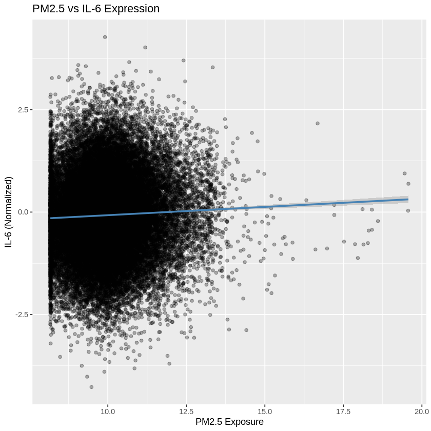

```r
ggplot(df_all_no_na, aes(x = pm25_2010, y = il6_rint)) +
  geom_point(alpha = 0.3) +
  geom_smooth(method = "lm", color = "steelblue") +
  labs(title = "PM2.5 vs IL-6 Expression",
       x = "PM2.5 Exposure", y = "IL-6 (Normalized)")
```

Scatterplot of PM2.5 and IL-6 with a fitted linear regression line. I'm seeing a very slight positive linear trend here consistent with my model.

### Calculate the R2 of PM2.5 to find the unique variance in IL-6 expression explained by PM2.5.

To do this manually I need to create a reduced model without PM2.5 then subtract the R2 of the reduced model from the full model to find PM2.5 R2.

```r
# Calculate the semi-partial R2 of PM2.5 manually
# Reduced model without PM2.5
model_no_pm25 <- lm(il6_rint ~ no2 + nox + age + sex + body_fat_percent,
                    data = df_all_no_na)

# Partial R² for PM2.5
r2_full <- summary(model_il6_pollution)$r.squared
r2_reduced <- summary(model_no_pm25)$r.squared
partial_r2_pm25 <- r2_full - r2_reduced

partial_r2_pm25
```

0.000257946321507357

This means that PM2.5 explains only about 0.026% of the variation in IL-6 expression. So although it has a statistically significant effect it's practical effect size on IL-6 is quite small in terms of variance explanied.

IL-6 is more strongly driven by sex, age, or % fat.